# Réplica: Credit Risk Analysis and Prediction Modelling of Bank Loans Using R

Carlos Arturo Cáceres Ojeda (caceresojeda@gmail.com)

**Artículo a Replicar:** *“Credit Risk Analysis and Prediction Modelling of Bank Loans Using R”*

**Año:** 2016

**Autor:** Sudhamathy G.

## 0. Introducción y Resumen General del Artículo

En el presente trabajo, se realizará un ejercicio de réplica de un modelo de Riesgo de Crédito utilizando los mismos datos del artículo original; además, se reconstruirá el código implementado por el autor con el fin de verificar si los resultados obtenidos son los mismos. De esta forma, a lo largo del presente trabajo se resume y replica cada uno de los pasos que el autor utilizó en el artículo original, partiendo desde el cargue la información en el software estadístico de R, el preprocesamiento de datos (como son la detección, ranking y eliminación de datos outlier y perdidos), selección de la muestra de entrenamiento y prueba, balanceo de la muestra de entrenamiento, selección de las variables (características) relevantes, para que finalmente se estime el modelo de riesgo de crédito, que a jucio del autor corresponde a un árbol de decisión, y se evalúe su desempeño dentro de la muestra de prueba.

De acuerdo con el autor, la importancia de evaluar a los posibles clientes de un Banco, con respecto a si aplican o no para el otorgamiento de un crédito, es crucial para minimizar y/o controlar las posibles pérdidas que puedan ocasionar que un subconjunto reducido de los clientes entren en *Default*. Por lo tanto, es necesario ser lo suficientemente exhaustivo en cada uno de los pasos implementados para la construcción del modelo de Riesgo de Crédito.

Por consiguiente, un punto a destacar dentro de cada uno de los pasos que el autor del artículo original usó para construir el modelo de riesgo de crédito final, corresponde con la implementación de diferentes modelos de machine learning para la detección, eliminación e imputación tanto de outliers como de valores perdidos; al igual, que en el proceso de selección de variables (características relevantes). De esta manera, el autor abarca dentro del artículo modelos como *KNN, Random Forest y Árbol de decisión* con el fin de obtener los resultados más precisos en términos de clasificación de clientes en los grupos de *Default* y *No Default*.

## 1. Selección de los Datos

De acuerdo con el artículo seleccionado, para estimar el *Probabilidad de Default (PD)* el autor utiliza el conjunto de datos de acceso libre en la red llamado *German Credit Scoring*, el cual contiene los siguientes 21 campos:

- A1: Estado Actual de la Deuda:
  - 1: < 0 DM
  - 2: < 200 DM
  - 3: >= 200 DM
  - 4: No existe deuda
- A2: Duración de la deuda en meses
- A3: Historial crediticio:
  - 0: No hay creditos tomados hasta ahora
  - 1: Todos los créditos que ha tenido el cliente en el banco están pagos
  - 2: Todos los créditos actuales del cliente han estado al día desde siempre
  - 3: El cliente ha tenido retrasos en pagos en el pasado
  - 4: Tiene créditos activos en otros bancos
- A4: Propósito de la Deuda
  - 0: Compra para carro nuevo
  - 1: Compra para carro usado
  - 2: Compra de muebles o equipos
  - 3: Compra para radio o televisión
  - 4: compra de electrodomésticos
  - 5: reparaciones o adecuaciones
  - 6: estudios
  - 7: vacaciones
  - 8: entrenamiento o deporte
  - 9: negocios
  - 10: otros
- A5: Monto del Préstamo (en DM)
- A6: Bonos / Ahorros:
  - 1: < 100 DM
  - 2: >= 100 and < 500 DM
  - 3: >= 500 DM and 1000 DM
  - 4: >= 1000 DM
  - 5: sin ahorros / sin bonos
- A7: Antigüedad del empleo
  - 1: desempleado
  - 2: < 1 año
  - 3: >= 1 y < 4 años
  - 4: >= 4 y < 7 años
  - 5: >= 7 años
- A8: Tasa de pago como porcentaje del ingreso disponible
- A9: Género y Estado Marital
  - 1: Divorciado (Hombre)
  - 2: Divorciada/Casada (Mujer)
  - 3: soltero (Hombre)
  - 4: Casado (Hombre)
  - 5: Soltera (Mujer)
- A10: Otras Deudas / Garantías
  - 1: Ninguno
  - 2: Coodeudor
  - 3: Garante/Fiador
- A11: Número de años viviendo en la residencia actual
- A12: Propiedades
  - 1: Biens Raíces
  - 2: Seguro de Vida
  - 3: Carro u otros bienes
  - 4: Sin propiedades
- A13: Edad en años
- A14: Otros deudas a cuotas
  - 1: Bancarias
  - 2: Almacenes
  - 3: Ninguna
- A15: Tipo de vivienda
  - 1: Arrendada
  - 2: Propia
  - 3: Familiar
- A16: Número de créditos activos en este banco
- A17: Estado laboral
  - 1: Desempleado no residente
  - 2: Desempleado residente
  - 3: Empleado calificado
  - 4: Independinte
- A18: Número de personas a cargo económicamente
- A19: Teléfono
  - 0: No disponible
  - 1: Disponible
- A20: Trabajador extranjero
  - 0: No
  - 1: Sí
- Def: Estado del Incumplimiento (Default)
  - 0: No Default
  - 1: Default

```r
library(readxl)
setwd("~/UNIVERSIDAD/Posgrado/Especializacion_Estadistica_2.0/Microeconometria")
creditdata <- read_excel("~/UNIVERSIDAD/Posgrado/Especializacion_Estadistica_2.0/Microeconometria/Datos_Banco_Aleman.xlsx")
creditdata<-as.data.frame(creditdata)
View(creditdata)
```

## 2. Preprocesamiento de Datos

De acuerdo con el autor, el preprocesamiento de datos consta de la detección, ranking, eliminación de outliers; al igual que de la imputación y de división de muestra de entrenamiento y prueba.

### A. Deteccion de Outliers

Los autores realizan un proceso de normalización de los datos cuantitativos y posteriormente grafican los resultados en diagrama de cajas, con el fin de verificar los valores por fuera del rango intercuartil.

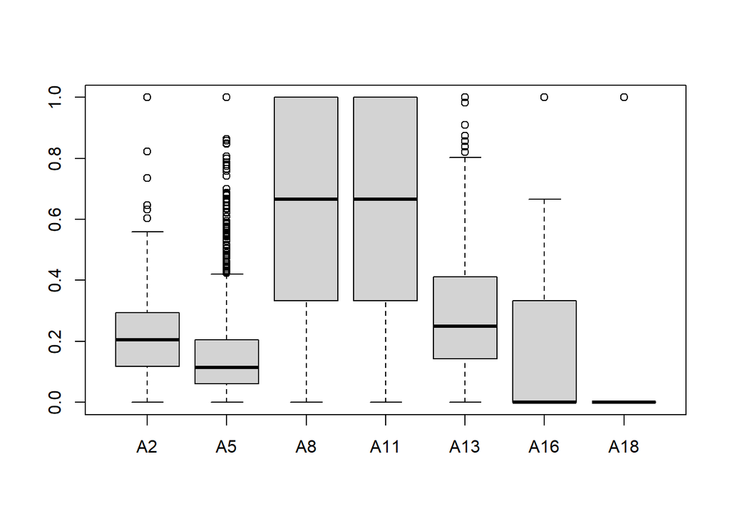

```r
# Crea función para normalizar los datos cuantitativos
normalizacion <- function(data,x)
{for(j in x)
{data[!(is.na(data[,j])),j]=
(data[!(is.na(data[,j])),j]-min(data[!(is.na(data[,j])),j]))/
(max(data[!(is.na(data[,j])),j])-min(data[!(is.na(data[,j])),j]))}
return(data)}

# Crea boxplot sobre los datos normalizados
c <- c(2,5,8,11,13,16,18)
normdata <- normalizacion(creditdata,c)
boxplot(normdata[,c])
```

### B. Ranking de Outliers

El autor utiliza el algoritmo de cluster jerárquico aglomerativo para ranquiar los outliers que son más fáciles y menos complejos de entender, de dal forma que utilizando éste algoritmo, que por medio de la distancia euclidiana, se crean grupos de obervaciones, y aquellos datos que estén más alejados que su promedio son calificadas como un outlier.

```r
require(cluster)
distance<-daisy(creditdata[,-19],stand=TRUE,metric=c("gower"), type =
list(interval=c(2,5,8,11,13,16,18),nominal=c(1,3,4,6,7,9,10,12,14,15,17),binary=c(19,20)))
require(DMwR)
outlierdata<-outliers.ranking(distance,test.data=NULL,method="sizeDiff",clus = list(dist="euclidean",
alg = "hclust", meth="average"), power = 1, verb = F)
```

### C. Eliminación de Outliers

El autor después de ranquier los datos, muestra que aquellas observaciones que tienen la probabilidad de ranking más baja son los que se deberían eliminar de la muestra, puesto que son observaciones que tienen probabilidad más baja de encontrar a otros datos con características similares.

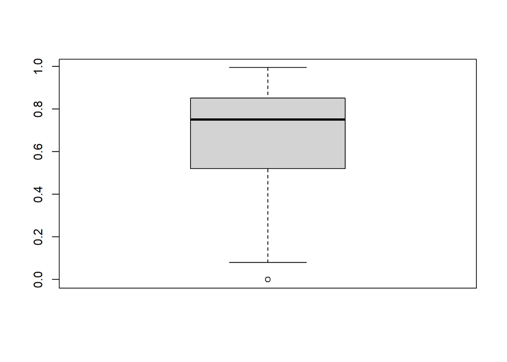

```r
boxplot(outlierdata$prob.outliers[outlierdata$rank.outliers])
```

```r
n <- quantile(outlierdata$rank.outliers)
n1 <-  n[1]
n4 <- n[4]

# Filtra los outliers que están por fuera del diagrama de cajas
filler<-(outlierdata$rank.outlier > n4*1.3)

# Crea la base de datos final sin tener en cuenta los outliers
creditdata_noout<-creditdata[!filler,]
# Total de observaciones sin outliers
nrow(creditdata_noout)
```

```
## [1] 975
```

### D. Imputación de Valores Perdidos

El autor utiliza el algoritmo *KNN* de vecino más cercano para realizar la imputación de los datos perdidos; sin embargo, la base de datos no presenta datos perdidos, de todas maneras la rutina en la implementación es la siguiente:

```r
require(DMwR)
creditdata_noout_noimp <- knnImputation(creditdata_noout, k = 5, scale = T, meth = "weighAvg", distData = NULL)
nrow(creditdata_noout_noimp)
```

```
## [1] 975
```

### E. División de la Muestra de Entrenamiento y de Prueba

Con el objetivo de que el modelo propuesto se pueda utilizar para pronosticar, se divide la muestra en un 80% para entrenamiento y un 20% para prueba; de esta, manera, el modelo será entrenado con el conjunto de datos de entrenamiento, y la clasificación final será con los datos de prueba.

```r
library(DMwR)
split<-sample(nrow(creditdata_noout_noimp), round(nrow(creditdata_noout_noimp)*0.8))
trainingdata <- creditdata_noout_noimp[split,]
testdata <- creditdata_noout_noimp[-split,]
```

### F. Balanceo de la Muestra de Entrenamiento

El autor balancea la muestra de acuerdo a una da las variables de la base de datos; como el objetivo es predecir el evento de *default*, el cual solo ocurre el 30% de las veces en la base de datos, se busca equilibrar la muestra para que tanto el evento de *Default* y *No Default* sea cada uno aproximadamente del 50%; esto facilita a que el algoritmo de clasificación no se incline a favor de la categoría con mayor frecuencia y por lo tanto genere errores en la clasificación final.

De esta manera, el autor usa la función *SMOTE* de *R*, la cual permite balancear la muestra utilizando como criterio el vecino más cercano sobre el evento de *Default* (clase menos frecuente):

```r
creditdata_noout_noimp_train=(trainingdata)
creditdata_noout_noimp_train$default <- factor(ifelse(creditdata_noout_noimp_train$Def == 1, "def", "nondef"))
creditdata_noout_noimp_train_smot <- SMOTE(default ~ ., creditdata_noout_noimp_train, k=5, perc.over = 500) #SMOTE siempre requiere un dataframe como insumo
summary(creditdata_noout_noimp_train_smot$default)
```

```
##    def nondef
##   1452   2420
```

```r
nrow(creditdata_noout_noimp_train_smot)
```

```
## [1] 3872
```

Se puede visualizar el antes y después del balanceo de la muestra de entrenamiento con el fin de continuar con la estimación del modelo:

```r
library(cluster)
dist1=daisy(creditdata_noout_noimp_train[,-21],stand=TRUE,metric=c("gower"), type =
list(interval=c(2,5,8,11,13,16,18), nominal=c(1,3,4,6,7,9,10,12,14,15,17),binary=c(19,20)))
```

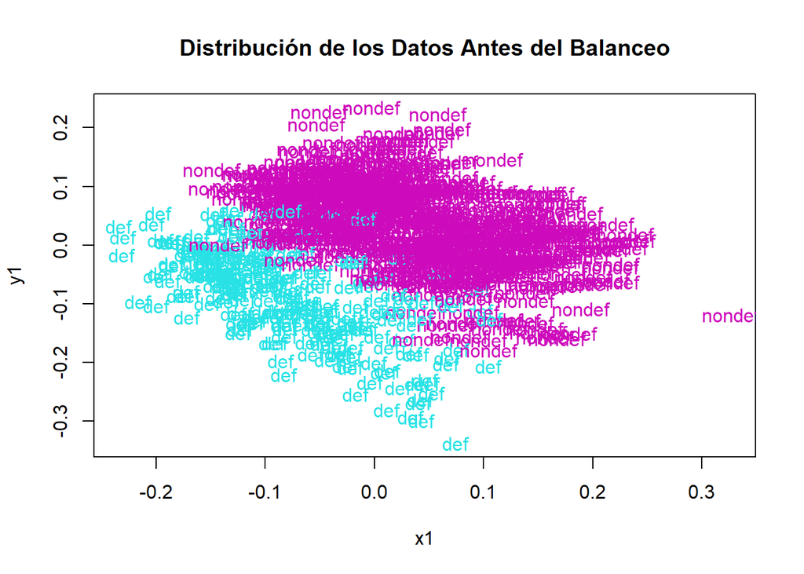

```r
dist2=daisy(creditdata_noout_noimp_train_smot[,-21],stand=TRUE,metric=c("gower"), type =
list(interval=c(2,5,8,11,13,16,18), nominal=c(1,3,4,6,7,9,10,12,14,15,17),binary=c(19,20)))
loc1=cmdscale(dist1,k=2)
loc2=cmdscale(dist2,k=2)
x1=loc1[,1]
y1=loc1[,2]
x2=loc2[,1]
y2=loc2[,2]

plot(x1,y1,type="n", main = "Distribución de los Datos Antes del Balanceo")
text(x1,y1,labels=creditdata_noout_noimp_train[,22],
col=as.numeric(creditdata_noout_noimp_train[,22])+4)
```

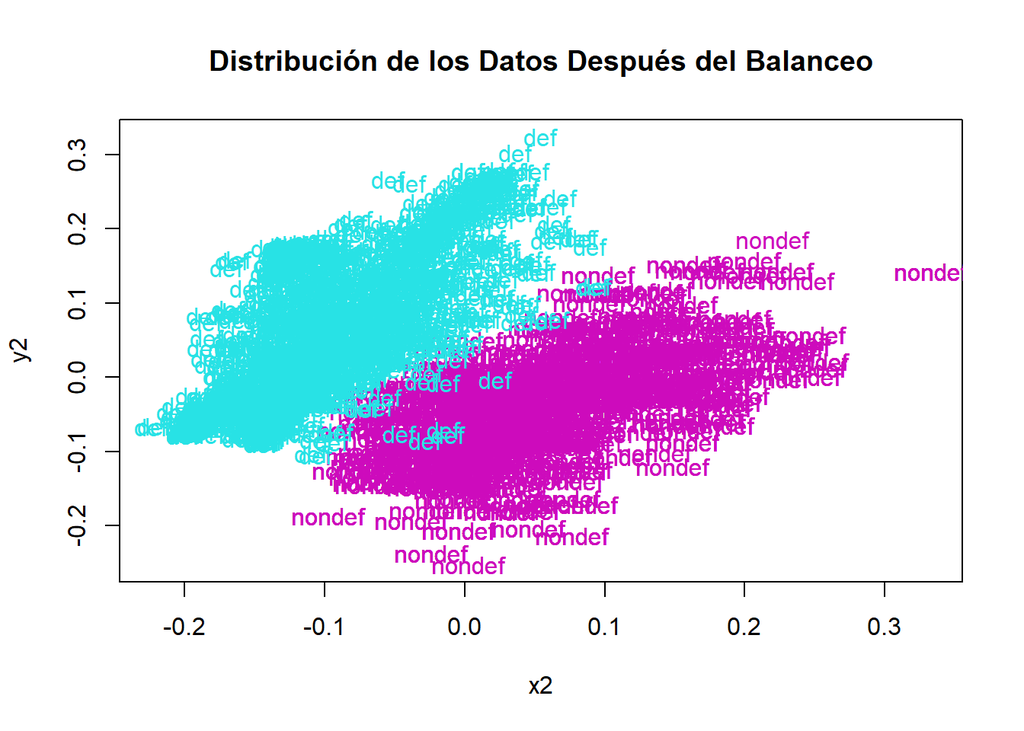

```r
plot(x2,y2,type="n", main = "Distribución de los Datos Después del Balanceo")
text(x2,y2,labels=creditdata_noout_noimp_train_smot[,22],
col=as.numeric(creditdata_noout_noimp_train_smot[,22])+4)
```

## 3. Selección de Características

### A. Análisis de Correlación

El autor separa el análisis de correlación para variables cuantitativas y cualitativas, y en ambas obitienen los gráficos de correlación entre variables; sin embargo, el autor concluye que no hay relación positiva fuerte entre variables:

```r
library(package="ellipse")
# Correlación entre Características Numéricas Continuas
c= c(2,5,8,11,13,16,18)
matriz_cor1 <- cor(creditdata_noout_noimp_train[,c])
matriz_cor1
```

```
##               A2          A5          A8        A11         A13         A16
## A2   1.000000000  0.61043998  0.07262869 0.05066445 -0.01737181 0.008177271
## A5   0.610439985  1.00000000 -0.30905239 0.06316856  0.05949721 0.048407526
## A8   0.072628691 -0.30905239  1.00000000 0.01183816  0.05610483 0.028075225
## A11  0.050664445  0.06316856  0.01183816 1.00000000  0.26701128 0.059078995
## A13 -0.017371810  0.05949721  0.05610483 0.26701128  1.00000000 0.122339498
## A16  0.008177271  0.04840753  0.02807522 0.05907900  0.12233950 1.000000000
## A18 -0.016118123  0.02356807 -0.04449795 0.02255204  0.10709742 0.078705350
##             A18
## A2  -0.01611812
## A5   0.02356807
## A8  -0.04449795
## A11  0.02255204
## A13  0.10709742
## A16  0.07870535
## A18  1.00000000
```

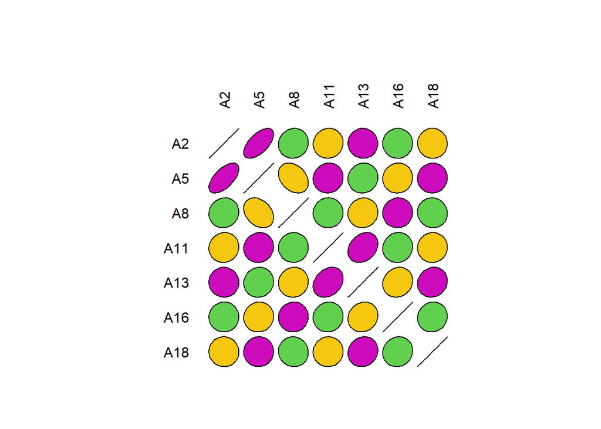

```r
plotcorr(matriz_cor1,col=cl<-c(7,6,3))
```

```r
# Correlación entre Características Cuantitativas Nominales
c= c(1,3,4,6,7,9,10,12,14,15,17)
matriz_cor2 <- cor(creditdata_noout_noimp_train [,c])
matriz_cor2
```

```
##               A1          A3           A4          A6          A7           A9
## A1   1.000000000  0.20715812  0.070109956  0.22134167  0.11210066  0.058956984
## A3   0.207158118  1.00000000 -0.093530554  0.05454489  0.09760072  0.027952284
## A4   0.070109956 -0.09353055  1.000000000 -0.02125538  0.02363395 -0.004000388
## A6   0.221341673  0.05454489 -0.021255377  1.00000000  0.13434636  0.044785585
## A7   0.112100662  0.09760072  0.023633946  0.13434636  1.00000000  0.071897923
## A9   0.058956984  0.02795228 -0.004000388  0.04478559  0.07189792  1.000000000
## A10 -0.145279291 -0.05207319 -0.049845752 -0.10458397 -0.03615880  0.029697493
## A12 -0.004164761 -0.05023373 -0.029117930  0.02511915  0.08659660 -0.026217634
## A14  0.035041934  0.12710839 -0.042978519 -0.01477617 -0.05812134 -0.032445489
## A15  0.016484844  0.06162139 -0.029424987  0.03039579  0.10638830  0.103529533
## A17  0.043996929  0.03092614 -0.027401634  0.01315010  0.11176362 -0.017998480
##             A10          A12          A14         A15          A17
## A1  -0.14527929 -0.004164761  0.035041934  0.01648484  0.043996929
## A3  -0.05207319 -0.050233726  0.127108394  0.06162139  0.030926139
## A4  -0.04984575 -0.029117930 -0.042978519 -0.02942499 -0.027401634
## A6  -0.10458397  0.025119152 -0.014776174  0.03039579  0.013150100
## A7  -0.03615880  0.086596595 -0.058121342  0.10638830  0.111763623
## A9   0.02969749 -0.026217634 -0.032445489  0.10352953 -0.017998480
## A10  1.00000000 -0.155925217 -0.046289438 -0.06613483 -0.062019346
## A12 -0.15592522  1.000000000 -0.101458207  0.36545359  0.264723879
## A14 -0.04628944 -0.101458207  1.000000000 -0.07628963 -0.009807704
## A15 -0.06613483  0.365453589 -0.076289627  1.00000000  0.106426850
## A17 -0.06201935  0.264723879 -0.009807704  0.10642685  1.000000000
```

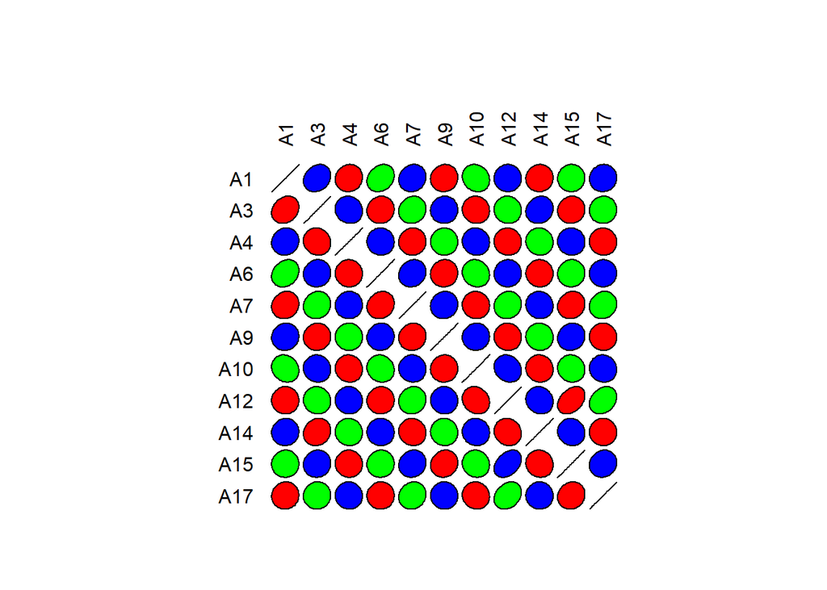

```r
plotcorr(matriz_cor2,col=cl<-c("green","red","blue"))
```

### B. Ranking de Características

El autor usa el algoritmo de *Random Forest* para crear un ranking de importancia en las variables del conjunto de datos, con el fin de seleccionar posteriormente un subconjunto de caracteristicas relevantes que puedan explicar a la totalidad de variables, para esto utiliza como criterio para el ranking de características la estimación de la precisión promedio:

```r
library(randomForest)
set.seed(454)
randf<-randomForest(Def~ ., data=data.frame(creditdata_noout_noimp_train), ntree=700, importance=TRUE, proximity=TRUE)
importance(randf, type=1, scale=TRUE)
```

```
##             %IncMSE
## A1        9.3561494
## A2        3.3595909
## A3        4.6762233
## A4        0.7827821
## A5        3.7509846
## A6        3.9166177
## A7        2.3493231
## A8        1.4880983
## A9       -1.1314094
## A10       3.7282698
## A11       1.0147883
## A12       1.5060853
## A13       3.0124089
## A14       1.9082319
## A15       1.6221217
## A16       2.3304088
## A17       0.8577520
## A18      -0.6170514
## A19       2.3610153
## A20      -1.0624097
## default 223.7081364
```

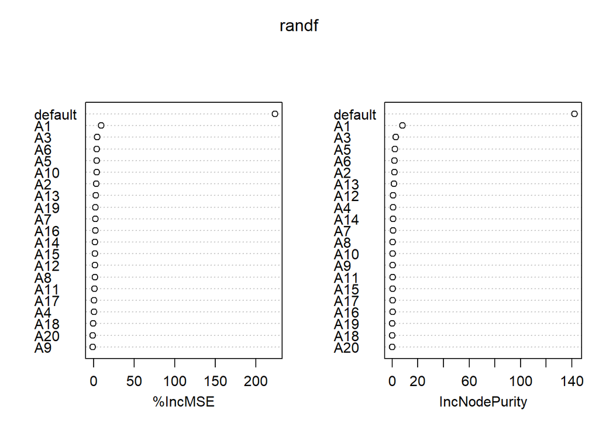

```r
varImpPlot(randf)
```

Debido a la naturaleza aleatoria del algoritmo de Ramdon Forest, los resultados de precisión del Error Cuadrático Medio estimado en el paso anterior difiere con los resultado del articulo. De esta manera, en la siguiente tabla se muestra el resultado del autor y el resultado previamente obtenido, lo cual influirá en que los resultados posteriores sean ligeramente diferentes a los del artículo seleccionado:

[output not shown]

### C. Selección de Características

El autor del artículo indica que se debe escoger un límite para seleccionar las características/variables relevantes para crear el modelo final, para esto, realiza un procedimiento de *Validación Cruzada* sobre la muestra de entrenamiento con 10 submuestras, el resultado es el siguiente:

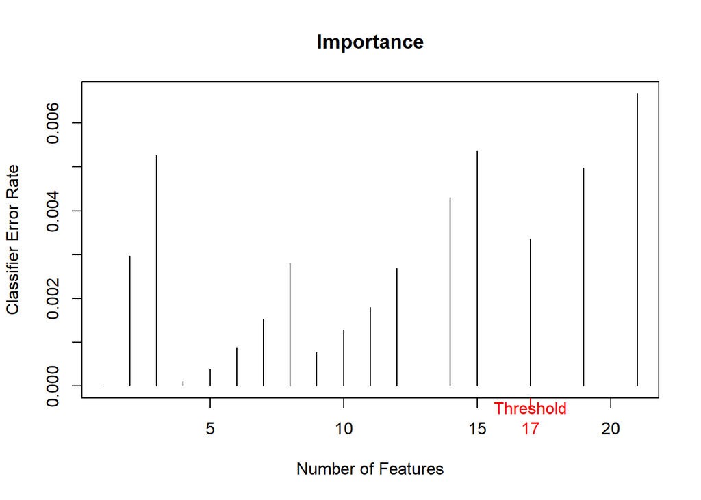

```r
findopt=rfcv(creditdata_noout_noimp_train[,-21], creditdata_noout_noimp_train[,21], cv.fold=10, scale="log", step=0.9)
opt <- which.min(findopt$error.cv)
plot(findopt$n.var, findopt$error.cv, type= "h", main = "Importance", xlab="Number of Features", ylab = "Classifier Error Rate")
axis(1, opt, paste("Threshold", opt, sep="\n"), col = "red", col.axis = "red")
```

De acuerdo con el resultado anterior, se muestra que las características (variables) relevantes seleccionadas son: A1, A2, A3, A4, A5, A6, A7, A8, A9, A10, A11, A12, A14, A15, A17, A19 y Def; sin embargo, el autor en el artículo muestra que sus resultados para las variables seleccionadas son: A1, A2, A3, A5, A6, A7, A9, A10, A12, A13, A14, A16, A19, A20 y Def. Es decir, el autor en sus resultados usan 15 variables (incluido el indicador de *Default*), mientras que los resultados aquí expuestos un total de 17 características (variables), donde una de ellas corresponde a la variable *Default*, para construir el modelo.

## 4. Construcción del Modelo

De acuerdo con el artículo, el modelo implementando para estimar la *probabilidad de Dafault* es el algoritmo de árbol de decisión. Debido a que los resultados de la selección de variables por parte del autor difiere con los expuestos aquí, se utilizarán las variables seleccionadas en este trabajo.

```r
#Estimación Árbol de Decisión
library(rpart)
c = c(13, 16, 18, 20, 22)
trdata=data.frame(creditdata_noout_noimp_train[,-c])
tree=rpart(trdata$Def~.,data=trdata,method="class")
printcp(tree)
```

```
##
## Classification tree:
## rpart(formula = trdata$Def ~ ., data = trdata, method = "class")
##
## Variables actually used in tree construction:
## [1] A1  A10 A11 A19 A2  A3  A5  A6  A7
##
## Root node error: 242/780 = 0.31026
##
## n= 780
##
##         CP nsplit rel error  xerror     xstd
## 1 0.055785      0   1.00000 1.00000 0.053387
## 2 0.024793      2   0.88843 0.99587 0.053326
## 3 0.016529      8   0.69835 0.93802 0.052422
## 4 0.012397      9   0.68182 0.94215 0.052490
## 5 0.010331     11   0.65702 0.90496 0.051861
## 6 0.010000     13   0.63636 0.90496 0.051861
```

```
## cex 0.788   xlim c(0, 1)   ylim c(0, 1)
```

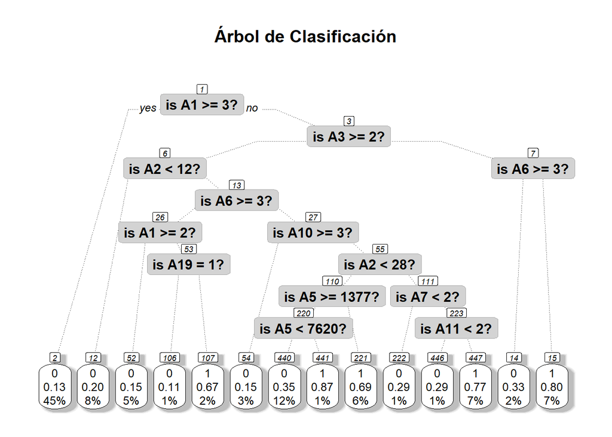

```r
#Visualización del Árbol de Clasificación
#plot(tree, uniform=TRUE,main="Classification Tree")
#text(tree, use.n=TRUE, all=TRUE, cex=0.7)

library(rpart.plot)
prp(tree, main="Árbol de Clasificación",
    extra=106,
    nn=TRUE,
    fallen.leaves=TRUE,
    branch=.5,
    faclen=0,
    trace=1,
    shadow.col="gray",
    branch.lty=3,
    split.cex=1.2,
    split.prefix="is ",
    split.suffix="?",
    split.box.col="lightgray",
    split.border.col="darkgray",
    split.round=.5)
```

## 5. Predicción del Modelo Evaluado

De acuerdo con el autor, para evaluar la capacidad predictiva del modelo, se debe utilizar la muestra de prueba sobre el modelo estimado con la muestra de entrenamiento con el fin de verificar si el modelo tiene buen comportamiento predictivo:

```r
#Predicción Modelo Autores
predicttest=data.frame(testdata)
pred=predict(tree,predicttest)
c=c(21)
pred<-table(predict(tree, testdata, type="class",na.action=na.pass), testdata[, c])
pred
```

```
##
##       0   1
##   0 131  35
##   1  11  18
```

**Nota:** a pesar de usar las mismas variables que el autor utiliza en el artículo, los resultados estimados fueron los mismos que los aquí expuestos. De esta manera, el resultado de los autores en el artículo y en el presente trabajo de réplica son los siguientes:

#### Resultado Autores en el Artículo

| Matriz de Confusión | Default | No Default |
| --- | --- | --- |
| **Default** | 30 | 5 |
| **No Default** | 6 | 154 |

#### Resultado del Presente Trabajo

| Matriz de Confusión | Default | No Default |
| --- | --- | --- |
| **Default** | 18 | 11 |
| **No Default** | 35 | 131 |

## 6. Evaluación del Modelo

Para la evaluación del modelo, el autor calcula las siguientes métricas sobre la matriz de confusión estimada: *Precision, Accuracy, TP Rate, FP Rate*.

$Precision = \frac{True\; Defaults}{True\; Defaults\; +\; False\; Defaults}$

$TP\; Rate = \frac{True\; Defaults}{Total\; Defaults}$

$FP\; Rate = \frac{False\; Defaults}{Total\; Nondefaults}$

```r
# Evalución de los Resultados en el Artículo
TD_paper <- 30
FD_paper <- 6
TND_paper <- 154
FND_paper <- 5
TotDef_paper <- TD_paper + FND_paper
TotNonDef_paper <- FD_paper + TND_paper
TotTest_paper <- TotDef_paper + TotNonDef_paper

Precision_paper <- TD_paper/(TD_paper + FD_paper)
Accuaracy_paper <- (TD_paper + TND_paper)/TotTest_paper
TP_Rate_paper <- TD_paper/TotDef_paper
FP_Rate_paper <- FD_paper/TotNonDef_paper

# Evaluacion de los Resultados en el Presente Trabajo
TD_propio <- pred[2,2]
FD_propio <- pred[1,2]
TND_propio <- pred[1,1]
FND_propio <- pred[2,1]
TotDef_propio <- TD_propio + FND_propio
TotNonDef_propio <- FD_propio + TND_propio
TotTest_propio <- TotDef_propio + TotNonDef_propio

Precision_propio <- TD_propio/(TD_propio + FD_propio)
Accuaracy_propio <- (TD_propio + TND_propio)/TotTest_propio
TP_Rate_propio <- TD_propio/TotDef_propio
FP_Rate_propio <- FD_propio/TotNonDef_propio

Precision_propio
```

```
## [1] 0.3396226
```

```r
Accuaracy_propio
```

```
## [1] 0.7641026
```

```r
TP_Rate_propio
```

```
## [1] 0.6206897
```

```r
FP_Rate_propio
```

```
## [1] 0.2108434
```

Los resultados de la evalución del modelo réplica y del resultado en el artículo es el siguiente:

| Evaluación | Artículo | Réplica |
| --- | --- | --- |
| **Precision** | 0.8333333 | 0.3396226 |
| **Accuracy** | 0.9435897 | 0.7641026 |
| **TP Rate** | 0.8571429 | 0.6206897 |
| **FP Rate** | 0.0375 | 0.2108434 |

## 7. Conclusión

De acuerdo con los resultados obtenidos en la réplica del artículo *“Credit Risk Analysis and Prediction Modelling of Bank Loans Using R”*, se evidencia que estos distan bastante de lo expuestos por el autor original; puesto que las métricas de evaluación tales como *Precision*, *Accuracy*, *TP Rate* y *FP Rate* -posterior a evaluar la muestra de prueba sobre el modelo estimado con la muestra de entrenamiento- no son tan precisas cuando se comparan con los resultados del artículo original. El motivo por el cual los resultados son diferentes, pueder ser a que la selección de las variables finales, al utilizar el algoritmo de *Random Forest*, fue diferente en la réplica con respecto al resultado expuesto en el artículo; otro argumento que pueda influenciar en las diferencias de resultados, puede ser por las versiones de los paquetes estadísticos; puesto que para el trabajo realizado en ésta réplica se han usado los paquetes de R más actualizados; mientras que los del artículo como máximo pueden ser con versiones del año 2016.

## 8. Bibliografía

Sudhamathy, G. (2016). Credit Risk Analysis and Prediction Modelling of Bank Loans Using R. International journal of engineering and technology, 8, 1954-1966.